# CSCI E-63C: Week 7 – Midterm Exam

Amy Wen

2019-03-22

# Sub-problem 1: load and summarize the data (25 points)

*Download and read in the data, produce numerical and graphical summaries of the dataset attributes, decide whether they can be used for modeling in untransformed form or any transformations are justified, comment on correlation structure and whether some of the predictors suggest relationship with the outcome. Plot observations in the dataset in the space of the first two principal components. Discuss relationships between dataset attributes and each of the first two principal components.*

Numerical summaries of the dataset attributes are given below. Graphical summaries with histograms showing their individual distributions and pairwise scatterplots showing their pairwise distributions are also shown.

Most of the variables can be used for modeling in untransformed form. Transaction date and house age seem to be generally uniformly distributed, and latititude seem to be generally normally distributed. Distance to nearest MRT station and number of convenience stores look to be more exponentially distributed and when compared against the outcome seems to have more spread at lower values, so log transformation of those variables would be justified. We may also want to log transform house price of unit area to reduce the effect of the particularly expensive house outlier. Longitude is left-skewed and has a strange relationship with the other variables (forming a mountain or checkmark shape), so it might require a more complex transformation for use in a linear model fit.

Distance to nearest MRT station has a fairly strong negative correlation with number of convenience stores, longitude, and latitude, which themselves are positively correlated with each other. The relationship between distance to nearest MRT station and longitude is especially apparent, with an almost straight line going down until around a longitude of 121.54 when the line abruptly changes to a positive slope.

There are general weak trends of increasing price with more recent transaction dates and lower house ages, but the variability is quite high in comparison to the slope. There is a stronger negative correlation between price and distance to nearest MRT station, as well as stronger positive correlations when price is compared against the remaining predictors (number of convenience stores, latitude, and longitude).

```r
# Read in the data
houseData = read_excel("Real estate valuation data set.xlsx")

# Look at data
head(houseData) # 6 explanantory variables (X1-X6) and 1 outcome (Y)
```

```
## # A tibble: 6 x 8
##      No `X1 transaction… `X2 house age` `X3 distance to… `X4 number of c…
##   <dbl>            <dbl>          <dbl>            <dbl>            <dbl>
## 1     1            2013.           32               84.9               10
## 2     2            2013.           19.5            307.                 9
## 3     3            2014.           13.3            562.                 5
## 4     4            2014.           13.3            562.                 5
## 5     5            2013.            5              391.                 5
## 6     6            2013.            7.1           2175.                 3
## # … with 3 more variables: `X5 latitude` <dbl>, `X6 longitude` <dbl>, `Y
## #   house price of unit area` <dbl>
```

```r
summary(houseData)
```

```
##        No        X1 transaction date  X2 house age
##  Min.   :  1.0   Min.   :2013        Min.   : 0.000
##  1st Qu.:104.2   1st Qu.:2013        1st Qu.: 9.025
##  Median :207.5   Median :2013        Median :16.100
##  Mean   :207.5   Mean   :2013        Mean   :17.713
##  3rd Qu.:310.8   3rd Qu.:2013        3rd Qu.:28.150
##  Max.   :414.0   Max.   :2014        Max.   :43.800
##  X3 distance to the nearest MRT station X4 number of convenience stores
##  Min.   :  23.38                        Min.   : 0.000
##  1st Qu.: 289.32                        1st Qu.: 1.000
##  Median : 492.23                        Median : 4.000
##  Mean   :1083.89                        Mean   : 4.094
##  3rd Qu.:1454.28                        3rd Qu.: 6.000
##  Max.   :6488.02                        Max.   :10.000
##   X5 latitude     X6 longitude   Y house price of unit area
##  Min.   :24.93   Min.   :121.5   Min.   :  7.60
##  1st Qu.:24.96   1st Qu.:121.5   1st Qu.: 27.70
##  Median :24.97   Median :121.5   Median : 38.45
##  Mean   :24.97   Mean   :121.5   Mean   : 37.98
##  3rd Qu.:24.98   3rd Qu.:121.5   3rd Qu.: 46.60
##  Max.   :25.01   Max.   :121.6   Max.   :117.50
```

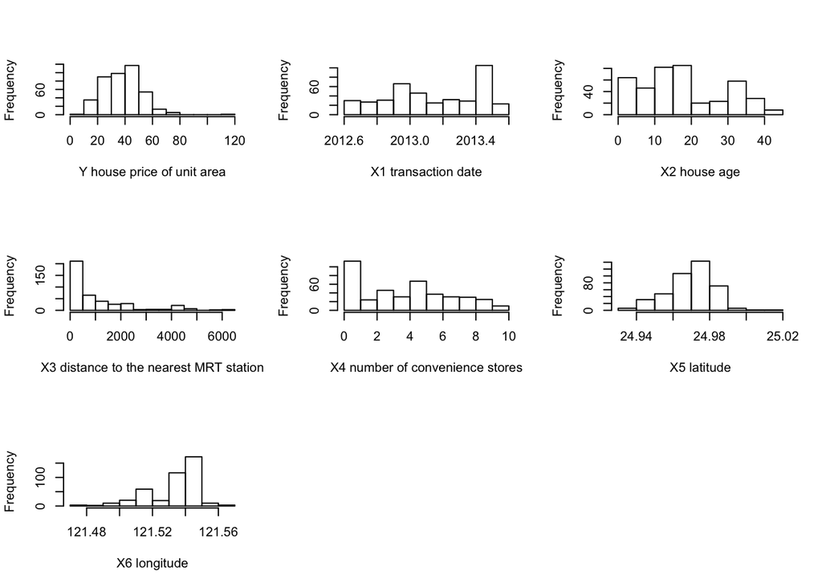

```r
# Rearrange so first column is outcome
houseData[1] = houseData[8]
names(houseData)[1] = names(houseData)[8]
houseData = houseData[-8]

# Plot histograms of the attributes
old.par <- par(mfrow=c(3,3))
for ( i.var in 1:ncol(houseData) )  {
  hist(houseData[[i.var]],xlab=names(houseData)[i.var], main="")
}
par(old.par)
```

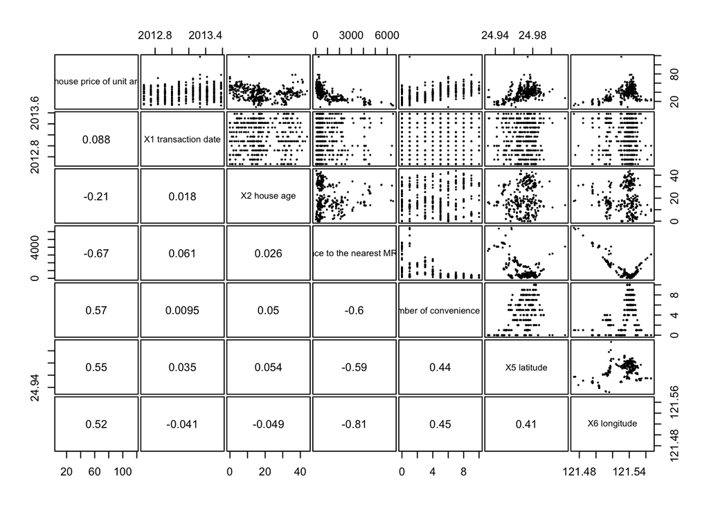

```r
# Calculate correlations between pairwise continuous attributes
pearson.cor <- function(x, y, ...)
{
  usr <- par("usr"); on.exit(par(usr))
  par(usr = c(0, 1, 0, 1))
  pearson <- signif(cor(x, y, method = "pearson"),2)
  txt <- paste0(pearson)
  text(0.5, 0.5, txt)
}

# Plot data pairwise and their correlations
pairs(houseData[1:ncol(houseData)], lower.panel = pearson.cor, gap=1/5, pch=16, cex=0.4)
```

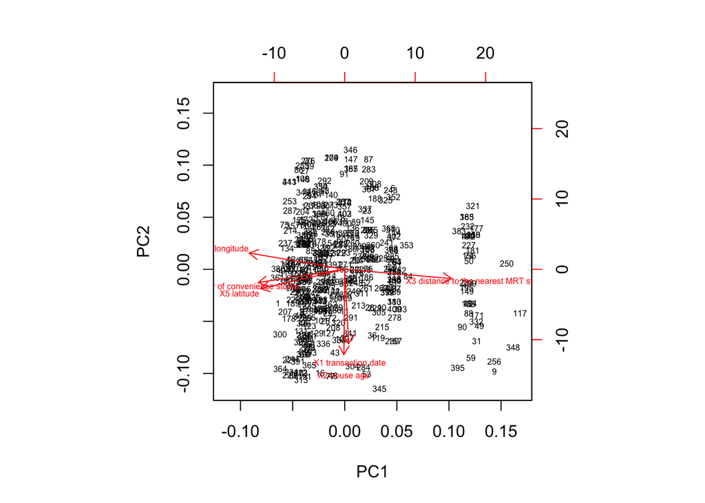

```r
### PCA of predictor attributes
PC = prcomp(houseData[2:ncol(houseData)], scal=TRUE) # Scale data

# plot(PC) # Scree plot
biplot(PC, cex=0.5) # Plot of the two first principal components
```

```r
# Attributes with largest loadings for the first and second principal components
PCA1 = sort(abs(PC$rotation[,1]))[ncol(houseData)-1]; PCA1 # Distance to nearest MRT station
```

```
## X3 distance to the nearest MRT station
##                              0.5705572
```

```r
PCA2 = sort(abs(PC$rotation[,2]))[ncol(houseData)-1]; PCA2 # House age
```

```
## X2 house age
##    0.7278927
```

# Sub-problem 2: multivariate linear model (25 points)

*Using function `lm` fit model of outcome as linear function of all predictors in the dataset. Present and discuss diagnostic plots. Report 99% confidence intervals for model parameters that are statistically significantly associated with the outcome and discuss directions of those associations. Obtain mean prediction (and corresponding 90% confidence interval) for a new observation with each attribute set to average of the observations in the dataset. Describe evidence for potential collinearity among predictors in the model.*

Linear fit of outcome as a function of all the predictors is performed below and the diagnostic plots shown. Some heteroskedasticity is observed from the residuals vs. fitted plot, with higher residuals observed especially in the 40-50 ranged of fitted values, with point 271 having a much higher residual than the others. We also see what appears to be two main clusters below and above fitted values of 20 for the price per unit area. From the normal qq plot, we see there is some evidence of non-normality due to the points not fitting the line at either end, with point 114 being unusual on the low end and 271 being unusual on the high end. The scale-location plot looks to be a fairly straight line across, and we again observe 271 having a particularly high residual. The residuals vs. leverage plot has all points within the threshold Cook’s distance. We do observe quite a few points with particularly high leverage but small residuals, and not surprisingly points 114 and 271 stand out in terms of residual values.

Since distance to the nearest MRT station, number of convenience stores, and price of unit area were identified as potentially benefitting from log transformations in sub-problem 1, a linear fit with log transformed variables was also performed (took log of (attribute+1) to account for 0’s in the data). Histograms of the log transformations show that price of unit area and distance to the nearest MRT station benefitted more from the transformations than number of convenience stores. Pairwise scatterplots of the 3 variables show more of a linear trend than previously observed between price of unit area and distance to the nearest MRT station. The linear fit has a better $R^2$ value than previously. The diagnostic plots are similar compared to previously, except 114 has the more extreme residual and 271 less so. There are some improvements that can be observed as well. Even though there is still some non-normality to the residuals, the spread and the extremeness of the residuals are slightly better. The high leverage points are have slightly reduced leverages.

The 99% confidence intervals for the model parameters were found for both the untransformed and transformed variables (shown below). There is a positive association of price with transaction date, number of convenience stores (only for untransformed; not significant at 99% for transformed), latitude, and longitude (only for transformed; not significant at 99% for untransformed), but a negative association with house age and distance to nearest MRT station. These results are pretty much as expected based on their pairwise correlations with price above.

The mean prediction with corresponding 90% confidence interval using original data and average observations for each attribute is: 37.98019 and (23.36002, 52.60037). With the log-transformed data, the values are very similar after transforming back, with a mean of 35.48386 and a smaller 90% confidence interval of (25.23111, 49.74403).

We have several pieces of evidence for potential collinearity among predictors in the model. From sub-problem 1, there was high pairwise correlations between some of the variables. Even though longitude was statistically significantly related to price in the log-transformed model, it was not at all deemed important with the untransformed variables (p-value of 0.798). Also, if we look at the VIFs of the variables, we observe VIFs above 2 for distance to the nearest MRT station (4.3) and longitude (2.9). Although these VIF values are not super high, they do indicate some collinearity among the predictors.

```r
# Linear fit as function of all predictors
houseFit = lm(houseData)
summary(houseFit)
```

```
##
## Call:
## lm(formula = houseData)
##
## Residuals:
##     Min      1Q  Median      3Q     Max
## -35.667  -5.412  -0.967   4.217  75.190
##
## Coefficients:
##                                            Estimate Std. Error t value
## (Intercept)                              -1.444e+04  6.775e+03  -2.132
## `X1 transaction date`                     5.149e+00  1.557e+00   3.307
## `X2 house age`                           -2.697e-01  3.853e-02  -7.000
## `X3 distance to the nearest MRT station` -4.488e-03  7.180e-04  -6.250
## `X4 number of convenience stores`         1.133e+00  1.882e-01   6.023
## `X5 latitude`                             2.255e+02  4.457e+01   5.059
## `X6 longitude`                           -1.243e+01  4.858e+01  -0.256
##                                          Pr(>|t|)
## (Intercept)                               0.03364 *
## `X1 transaction date`                     0.00103 **
## `X2 house age`                           1.06e-11 ***
## `X3 distance to the nearest MRT station` 1.04e-09 ***
## `X4 number of convenience stores`        3.83e-09 ***
## `X5 latitude`                            6.38e-07 ***
## `X6 longitude`                            0.79820
## ---
## Signif. codes:  0 '***' 0.001 '**' 0.01 '*' 0.05 '.' 0.1 ' ' 1
##
## Residual standard error: 8.858 on 407 degrees of freedom
## Multiple R-squared:  0.5824, Adjusted R-squared:  0.5762
## F-statistic:  94.6 on 6 and 407 DF,  p-value: < 2.2e-16
```

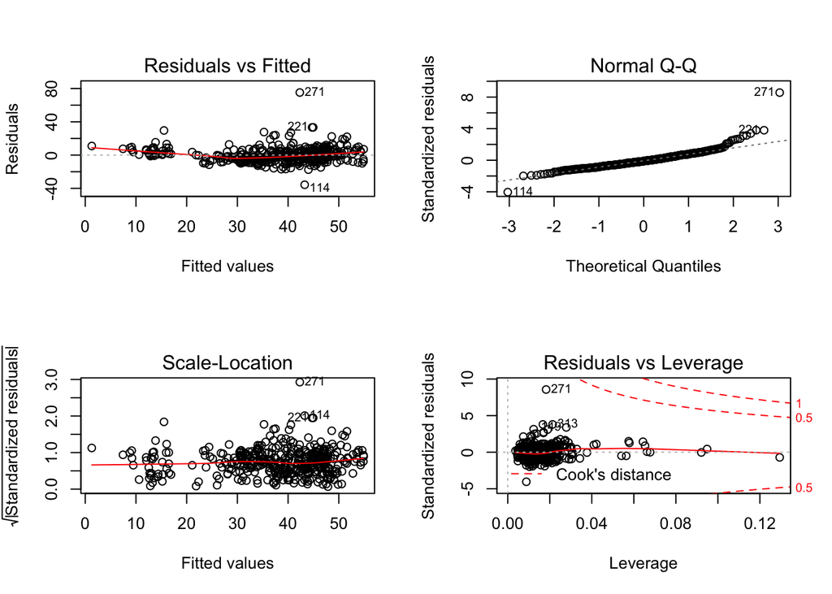

```r
# Diagnostic plots
old.par <- par(mfrow=c(2,2))
plot(houseFit) # Diagnostic plots
```

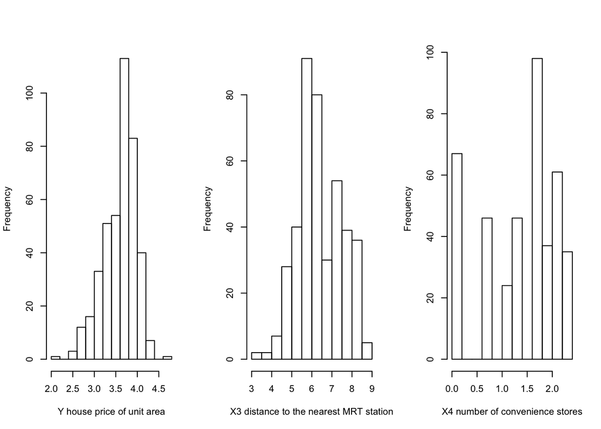

```r
par(old.par)

# Log transform some variables
houseDataLog = houseData
houseDataLog[1]=log(houseData[1]+1) # House price of unit area (outcome)
houseDataLog[4]=log(houseData[4]+1) # Distance to nearest MRT station
houseDataLog[5]=log(houseData[5]+1) # Number of convenience stores

# Look at effect of log transformation
# Plot histograms of the attributes
old.par <- par(mfrow=c(1,3))
for ( i.var in c(1,4,5) )  {
  hist(houseDataLog[[i.var]],xlab=names(houseData)[i.var], main="")
}
```

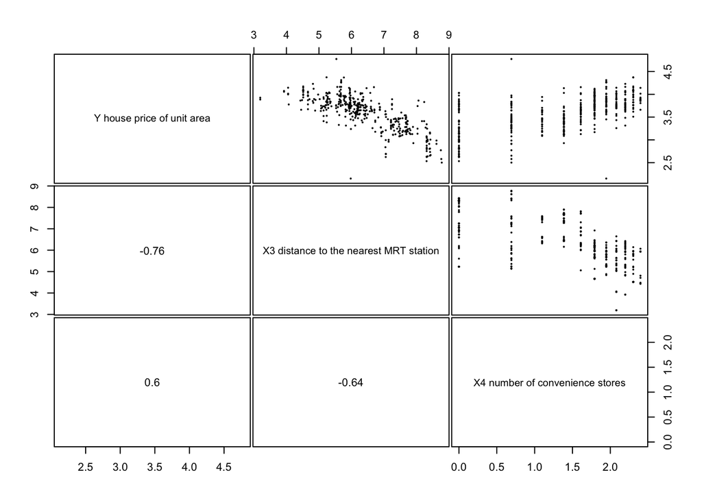

```r
par(old.par)

# Plot pairwise distribution of log-transformed variables
pairs(houseDataLog[c(1,4,5)], lower.panel = pearson.cor, gap=1/5, pch=16, cex=0.4)
```

```r
# Linear fit with log transform of some of the predictors
houseFitLog = lm(houseDataLog)
summary(houseFitLog)
```

```
##
## Call:
## lm(formula = houseDataLog)
##
## Residuals:
##      Min       1Q   Median       3Q      Max
## -1.52984 -0.10244  0.00661  0.09880  0.94947
##
## Coefficients:
##                                            Estimate Std. Error t value
## (Intercept)                              -8.521e+02  1.231e+02  -6.920
## `X1 transaction date`                     1.607e-01  3.530e-02   4.551
## `X2 house age`                           -5.771e-03  8.713e-04  -6.623
## `X3 distance to the nearest MRT station` -1.690e-01  1.392e-02 -12.136
## `X4 number of convenience stores`         4.536e-02  1.753e-02   2.587
## `X5 latitude`                             9.453e+00  9.464e-01   9.989
## `X6 longitude`                            2.447e+00  8.568e-01   2.856
##                                          Pr(>|t|)
## (Intercept)                              1.76e-11 ***
## `X1 transaction date`                    7.05e-06 ***
## `X2 house age`                           1.12e-10 ***
## `X3 distance to the nearest MRT station`  < 2e-16 ***
## `X4 number of convenience stores`         0.01002 *
## `X5 latitude`                             < 2e-16 ***
## `X6 longitude`                            0.00451 **
## ---
## Signif. codes:  0 '***' 0.001 '**' 0.01 '*' 0.05 '.' 0.1 ' ' 1
##
## Residual standard error: 0.1999 on 407 degrees of freedom
## Multiple R-squared:  0.7262, Adjusted R-squared:  0.7222
## F-statistic: 179.9 on 6 and 407 DF,  p-value: < 2.2e-16
```

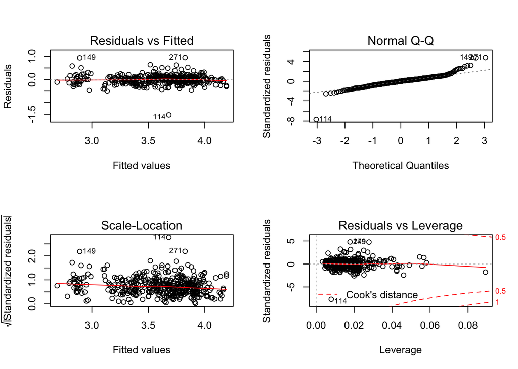

```r
# Diagnostic plots for log-transformed plots
old.par <- par(mfrow=c(2,2))
plot(houseFitLog) # Diagnostic plots
```

```r
par(old.par)

# 99% confidence intervals for model parameters (untrasformed and log-transformed model)
confint(houseFit, level=0.99)
```

```
##                                                  0.5 %        99.5 %
## (Intercept)                              -3.197643e+04 3092.46437463
## `X1 transaction date`                     1.119879e+00    9.17815538
## `X2 house age`                           -3.694109e-01   -0.16998258
## `X3 distance to the nearest MRT station` -6.345696e-03   -0.00262932
## `X4 number of convenience stores`         6.463748e-01    1.62027520
## `X5 latitude`                             1.101356e+02  340.80471142
## `X6 longitude`                           -1.381553e+02  113.29719289
```

```r
confint(houseFitLog, level=0.99)
```

```
##                                                  0.5 %        99.5 %
## (Intercept)                              -1.170764e+03 -5.334381e+02
## `X1 transaction date`                     6.930175e-02  2.519989e-01
## `X2 house age`                           -8.025552e-03 -3.515569e-03
## `X3 distance to the nearest MRT station` -2.050209e-01 -1.329499e-01
## `X4 number of convenience stores`        -1.055870e-05  9.073507e-02
## `X5 latitude`                             7.003917e+00  1.190237e+01
## `X6 longitude`                            2.294000e-01  4.664217e+00
```

```r
# Mean prediction and corresponding 90% confidence interval (untransformed model)
means = houseData[1,] # Initialize tibble with first row of houseData
for ( i.var in 1:ncol(houseData) )  {
  means[[i.var]] = mean(houseData[[i.var]]) # Populate with average observations
}
predict(houseFit, newdata=means[-1], interval="prediction", level=0.9)
```

```
##        fit      lwr      upr
## 1 37.98019 23.36002 52.60037
```

```r
# Mean prediction and corresponding 90% confidence interval (log-transformed model)
meansLog = houseDataLog[1,] # Initialize tibble with first row of houseData
for ( i.var in 1:ncol(houseData) )  {
  meansLog[[i.var]] = mean(houseDataLog[[i.var]]) # Populate with average observations
}
exp(predict(houseFitLog, newdata=meansLog[-1], interval="prediction", level=0.9))-1 # Transform back
```

```
##        fit      lwr      upr
## 1 35.48386 25.23111 49.74403
```

```r
# Evidence of potential collinearity among predictors
vif(houseFit) # Variance inflation factor
```

```
##                    `X1 transaction date`
##                                 1.014655
##                           `X2 house age`
##                                 1.014287
## `X3 distance to the nearest MRT station`
##                                 4.322984
##        `X4 number of convenience stores`
##                                 1.617021
##                            `X5 latitude`
##                                 1.610225
##                           `X6 longitude`
##                                 2.926305
```

```r
vif(houseFitLog)
```

```
##                    `X1 transaction date`
##                                 1.024177
##                           `X2 house age`
##                                 1.018625
## `X3 distance to the nearest MRT station`
##                                 2.498800
##        `X4 number of convenience stores`
##                                 1.868238
##                            `X5 latitude`
##                                 1.425946
##                           `X6 longitude`
##                                 1.787461
```

# Sub-problem 3: choose optimal models by exhaustive, forward and backward selection (15 points)

*Use `regsubsets` from library `leaps` to choose optimal set of variables for modeling real estate valuation and describe differences and similarities between attributes deemed most important by these approaches.*

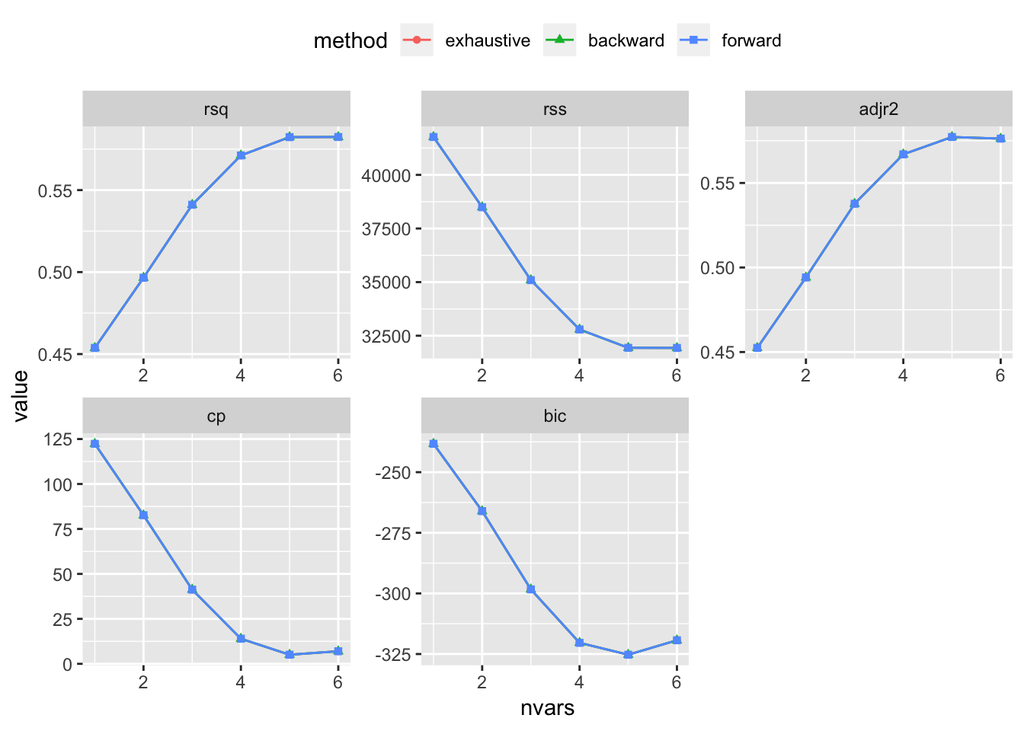

```r
# Exhaustive, forward, and backward selection
# Use `regsubsets` to choose optimal set of variables for modeling real estate valuation
summaryMetrics <- NULL
whichAll <- list()
Methods <- c("exhaustive", "backward", "forward")
houseData = data.frame(houseData)
for ( myMthd in Methods ) {
  rsRes <- regsubsets(Y.house.price.of.unit.area~., houseData, method=myMthd)
  summRes <- summary(rsRes)
  whichAll[[myMthd]] <- summRes$which
  for ( metricName in c("rsq","rss","adjr2","cp","bic") ) {
    summaryMetrics <- rbind(summaryMetrics,
                            data.frame(method=myMthd,metric=metricName,
                                       nvars=1:length(summRes[[metricName]]),
                                       value=summRes[[metricName]]))
  }
}

# Plot model metrics (rsq, rss, etc.)
ggplot(summaryMetrics,aes(x=nvars,y=value,shape=method,colour=method)) + geom_path() + geom_point() + facet_wrap(~metric,scales="free") +   theme(legend.position="top")
```

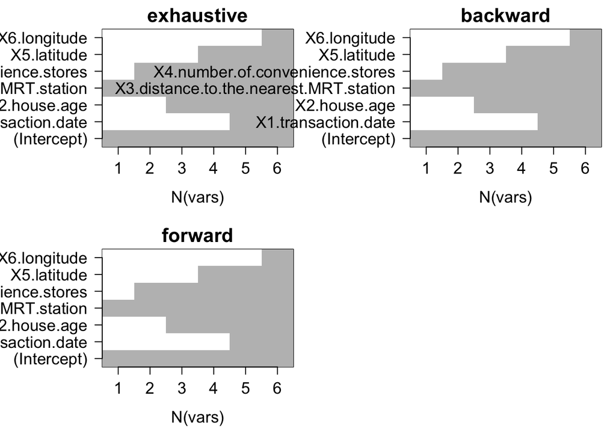

```r
# Plot which variables are included in the models
old.par <- par(mfrow=c(2,2),ps=16,mar=c(5,7,2,1))
for ( myMthd in names(whichAll) ) {
  image(1:nrow(whichAll[[myMthd]]),
        1:ncol(whichAll[[myMthd]]),
        whichAll[[myMthd]],xlab="N(vars)",ylab="",
        xaxt="n",yaxt="n",breaks=c(-0.5,0.5,1.5),
        col=c("white","gray"),main=myMthd)
  axis(1,1:nrow(whichAll[[myMthd]]),rownames(whichAll[[myMthd]]))
  axis(2,1:ncol(whichAll[[myMthd]]),colnames(whichAll[[myMthd]]),las=2)
}
par(old.par)
```

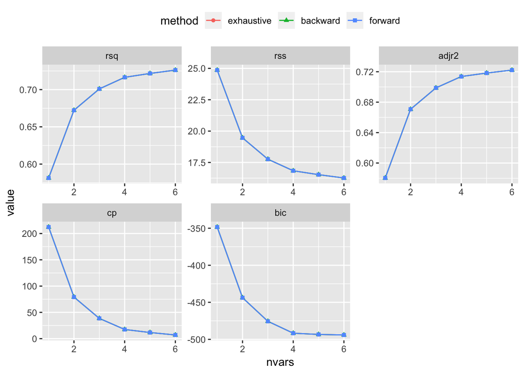

```r
## Do the same for log transformed variables
# Use `regsubsets` to choose optimal set of variables for modeling real estate valuation
summaryMetricsLog <- NULL
whichAllLog <- list()
houseDataLog = data.frame(houseDataLog)
for ( myMthd in Methods ) {
  rsResLog <- regsubsets(Y.house.price.of.unit.area~., houseDataLog, method=myMthd)
  summResLog <- summary(rsResLog)
  whichAllLog[[myMthd]] <- summResLog$which
  for ( metricName in c("rsq","rss","adjr2","cp","bic") ) {
    summaryMetricsLog <- rbind(summaryMetricsLog,
                            data.frame(method=myMthd,metric=metricName,
                                       nvars=1:length(summResLog[[metricName]]),
                                       value=summResLog[[metricName]]))
  }
}

# Plot model metrics (rsq, rss, etc.)
ggplot(summaryMetricsLog,aes(x=nvars,y=value,shape=method,colour=method)) + geom_path() + geom_point() + facet_wrap(~metric,scales="free") +   theme(legend.position="top")
```

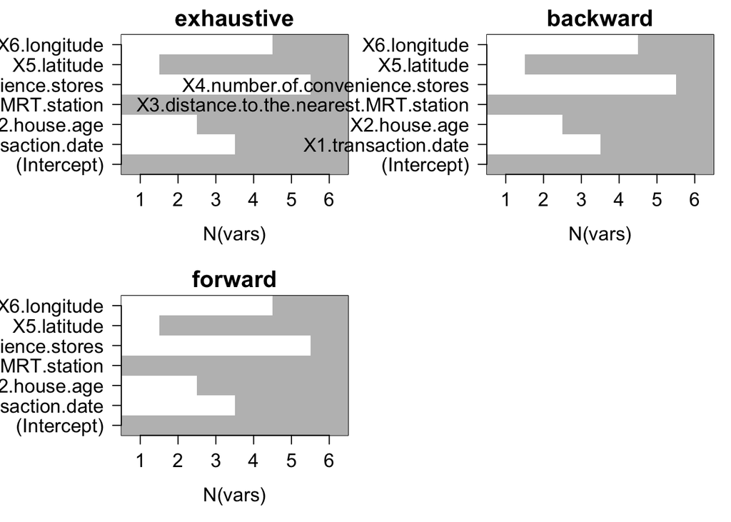

```r
# Plot which variables are included in the models
old.par <- par(mfrow=c(2,2),ps=16,mar=c(5,7,2,1))
for ( myMthd in names(whichAllLog) ) {
  image(1:nrow(whichAllLog[[myMthd]]),
        1:ncol(whichAllLog[[myMthd]]),
        whichAllLog[[myMthd]],xlab="N(vars)",ylab="",
        xaxt="n",yaxt="n",breaks=c(-0.5,0.5,1.5),
        col=c("white","gray"),main=myMthd)
  axis(1,1:nrow(whichAllLog[[myMthd]]),rownames(whichAllLog[[myMthd]]))
  axis(2,1:ncol(whichAllLog[[myMthd]]),colnames(whichAllLog[[myMthd]]),las=2)
}
par(old.par)
```

# Sub-problem 4: optimal model by cross-validation (20 points)

*Use cross-validation (or any other resampling strategy of your choice) to estimate test error for models with different numbers of variables. Compare and comment on the number of variables deemed optimal by resampling versus those selected by `regsubsets` in the previous task.*

Cross-validation to estimate test error for models with different numbers of variables is performed below. Since the subsets for each selection method was the same, not surprisngly no differences were found between the different methods. The testing mse only marginally improves with additional variables after 4 variables, both for untransformed and log-transformed data, so we find that around 4-5 variables is deemed optimal using cross-validation, which is similar to the ~5 variables selected by `regsubsets` previously.

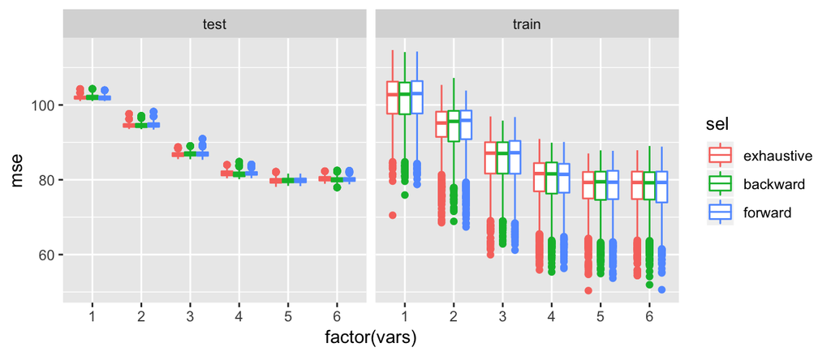

```r
# Crossvalidation function from lecture
xval = function (x, data, N.xval=5, N.iter=100, prefix=substitute(x)) {
  if ( class(x) == "formula" ) f = x
  else f = as.list(x$call)$formula
  mse.test = numeric(N.iter)
  mse.train = numeric(N.iter*N.xval)

  for ( iter in 1:N.iter ) {
    grps = sample( (1:nrow(data))  %% N.xval+1 )
    test.residuals = numeric()
    for ( i in 1:N.xval ) {
      data.test = data[grps == i,] # Set group i as train
      data.train = data[grps != i,] # Set the rest as train
      M = lm(f, data=data.train, na.action="na.exclude")
      M.predicted = predict(M, newdata=data.test)
      r = M.predicted - data.test[,1] # Outcome (should be first column)
      test.residuals = c(test.residuals, r^2)
      mse.train[(iter-1)*N.xval+i] = sum(M$residuals^2, na.rm=T)/sum(!is.na(M$residuals))
    }
    mse.test[iter] = mean(test.residuals, na.rm=T)
  }
  l = list(MSE.train=mse.train, MSE.test=mse.test)
  names(l) = c("train", "test")
return(l)
}

dfTmp <- NULL

# Try each method available in regsubsets to select the best model of each size:
for ( jSelect in Methods ) {
  rsRes <- regsubsets(Y.house.price.of.unit.area~., houseData, method=jSelect)
  s = summary(rsRes)
  mse = list()
  mean.mse = numeric()

  # Calculate test error for cross-validation for each number of variables using xval from above
  for ( i in 1:6 ) {
    l = xval(Y.house.price.of.unit.area~., data=houseData[s$which[i,]], prefix=i)
    mean.mse[i] = mean(l[[2]])
    dfTmp <- rbind(dfTmp,data.frame(sel=jSelect,vars=i,mse=l))
  }
}

# Plot MSEs by training/test, number of variables and selection method:
dfTmp.tidy = dfTmp %>% gather(key, mse, -c(sel, vars)) %>% separate(key, c("extra column","trainTest"), "\\.") # mse.train and mse.test become mse and train/test
ggplot(dfTmp.tidy,aes(x=factor(vars),y=mse,color=sel)) + geom_boxplot()+facet_wrap(~trainTest)
```

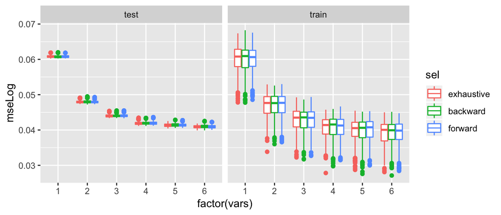

```r
## Do the same for log transformed variables
dfTmp <- NULL

# Try each method available in regsubsets to select the best model of each size:
for ( jSelect in Methods ) {
  rsResLog <- regsubsets(Y.house.price.of.unit.area~., houseDataLog, method=jSelect)
  sLog = summary(rsResLog)
  mseLog = list()
  mean.mseLog = numeric()

  # Calculate test error for cross-validation for each number of variables using xval from above
  for ( i in 1:6 ) {
    lLog = xval(Y.house.price.of.unit.area~., data=houseDataLog[sLog$which[i,]], prefix=i)
    mean.mseLog[i] = mean(lLog[[2]])
    dfTmp <- rbind(dfTmp,data.frame(sel=jSelect,vars=i,mseLog=lLog))
  }
}

# Plot MSEs by training/test, number of variables and selection method:
dfTmp.tidy = dfTmp %>% gather(key, mseLog, -c(sel, vars)) %>% separate(key, c("extra column","trainTest"), "\\.") # mse.train and mse.test become mse and train/test
ggplot(dfTmp.tidy,aes(x=factor(vars),y=mseLog,color=sel)) + geom_boxplot()+facet_wrap(~trainTest)
```

# Sub-problem 5: variable selection by lasso (15 points)

*Use regularized approach (i.e. lasso) to model property valuation. Compare resulting models (in terms of number of variables and their effects) to those selected in the previous two tasks (by `regsubsets` and resampling), comment on differences and similarities among them.*

For log-transformed variables, all 6 variables were included by lasso regression for minimum MSE and 5 variables for 1SE away. This matches what was found by `regsubsets` and minimizing cp value but is greater than 4-5 variables found using cross-validation.

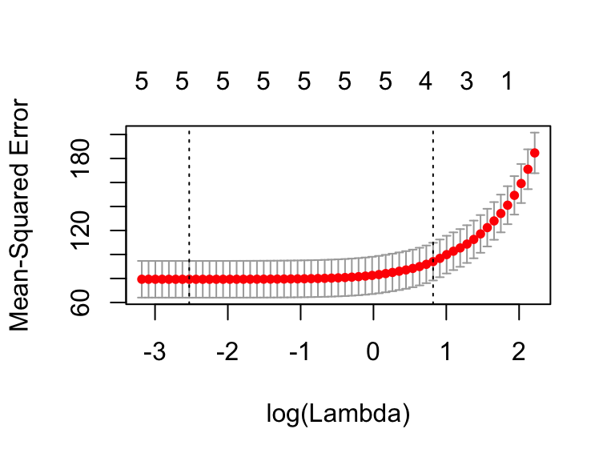

```r
# Prepare matrices for glmnet
# -1 to get rid of intercept that glmnet knows to include:
x <- model.matrix(Y.house.price.of.unit.area~., houseData)[,-1]
y <- houseData[,"Y.house.price.of.unit.area"]

# Perform lasso regression and cross-validation
lassoRes <- glmnet(x,y,alpha=1)
# plot(lassoRes)
cvLassoRes <- cv.glmnet(x,y,alpha=1)
plot(cvLassoRes)
```

```r
# cvLassoRes$lambda.min # 0.08738346
# cvLassoRes$lambda.1se # 2.488712

# Coefficient values at cross-validation minimum MSE and that 1SE away
predict(lassoRes,type="coefficients",s=cvLassoRes$lambda.min)
```

```
## 7 x 1 sparse Matrix of class "dgCMatrix"
##                                                    1
## (Intercept)                            -1.529849e+04
## X1.transaction.date                     4.851205e+00
## X2.house.age                           -2.618962e-01
## X3.distance.to.the.nearest.MRT.station -4.331646e-03
## X4.number.of.convenience.stores         1.120413e+00
## X5.latitude                             2.232772e+02
## X6.longitude                            .
```

```r
predict(lassoRes,type="coefficients",s=cvLassoRes$lambda.1se)
```

```
## 7 x 1 sparse Matrix of class "dgCMatrix"
##                                                    1
## (Intercept)                            -2.924485e+03
## X1.transaction.date                     .
## X2.house.age                           -5.699303e-02
## X3.distance.to.the.nearest.MRT.station -3.817756e-03
## X4.number.of.convenience.stores         6.701027e-01
## X5.latitude                             1.187419e+02
## X6.longitude                            .
```

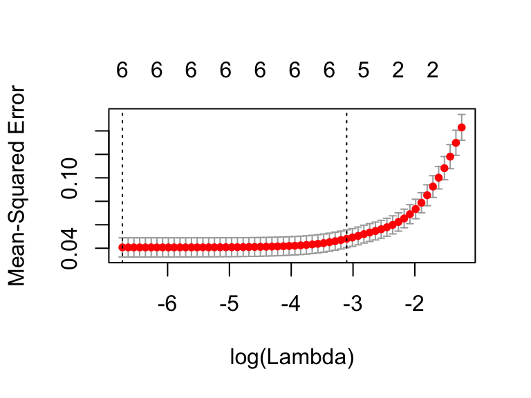

```r
## Do the same for log transformed variables
# Prepare matrices for glmnet
# -1 to get rid of intercept that glmnet knows to include:
xLog <- model.matrix(Y.house.price.of.unit.area~., houseDataLog)[,-1]
yLog <- houseDataLog[,"Y.house.price.of.unit.area"]

# Perform lasso regression and cross-validation
lassoResLog <- glmnet(xLog,yLog,alpha=1)
# plot(lassoResLog)
cvLassoResLog <- cv.glmnet(xLog,yLog,alpha=1)
plot(cvLassoResLog)
```

```r
# cvLassoResLog$lambda.min # 0.001193214
# cvLassoResLog$lambda.1se # 0.03729648

# Coefficient values at cross-validation minimum MSE and that 1SE away
predict(lassoResLog,type="coefficients",s=cvLassoResLog$lambda.min)
```

```
## 7 x 1 sparse Matrix of class "dgCMatrix"
##                                                    1
## (Intercept)                            -8.377455e+02
## X1.transaction.date                     1.562818e-01
## X2.house.age                           -5.663328e-03
## X3.distance.to.the.nearest.MRT.station -1.687624e-01
## X4.number.of.convenience.stores         4.469009e-02
## X5.latitude                             9.402610e+00
## X6.longitude                            2.411413e+00
```

```r
predict(lassoResLog,type="coefficients",s=cvLassoResLog$lambda.1se)
```

```
## 7 x 1 sparse Matrix of class "dgCMatrix"
##                                                    1
## (Intercept)                            -3.230229e+02
## X1.transaction.date                     .
## X2.house.age                           -1.743613e-03
## X3.distance.to.the.nearest.MRT.station -1.596921e-01
## X4.number.of.convenience.stores         2.082943e-02
## X5.latitude                             7.533676e+00
## X6.longitude                            1.148115e+00
```

# Extra points problem: using higher order terms (5 points)

*Evaluate the impact of adding non-linear terms to the model. Describe which terms, if any, warrant addition to the model and what is the evidence supporting their inclusion as well as the effect of their incorporation on model coefficients and error.*

# Extra points problem: using clusters instead of latitude/longitude (15 points)

*From the inspection of latitude and longitude attributes of this dataset you may have already noticed that they are distributed fairly unevenly (likely reflecting population density in the area represented by this data). Consequently, one may argue that using these two attributes as continuous predictors for the purposes of modeling is poorly justified and the resulting corresponding model coefficients are hardly indicative of change in property valuation with one unit of change in latitude/longitude values. This extra points problem invites you to use K-means clustering in the space of these two attributes to assign observations to progressively increasing number of clusters, use resulting cluster id as a factor attribute for the purposes of modeling instead of actual longitude/latitude coordinates and evaluate the impact of this transformation on model performance metrics. Compare this approach to the stratification by district employed in [Ye & Hsu, 2018](https://canvas.harvard.edu/files/7587373/download?download_frd=1) available at our course website in canvas.*

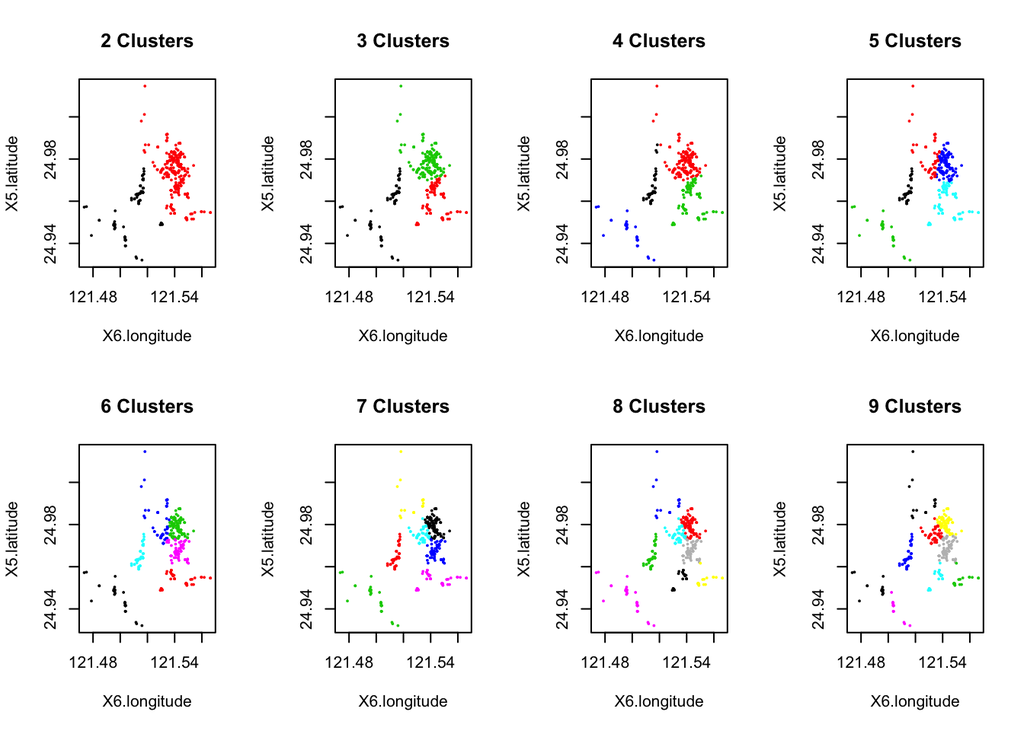

```r
# Loop over values of clusters
oldpar = par(mfrow=c(2,4)) # 2 by 4 graphing region
clusters = NULL
for (i.nclusters in 2:9) {
  # Set RNG seed
  set.seed(1)

  # Perform K-means clustering with i.nclusters clusters and nstart of 100
  cluster = kmeans(houseData[6:7], centers=i.nclusters, nstart=100)

  # Color by cluster
  plot(houseData[7:6], col=cluster$cluster, main=paste0(i.nclusters, " Clusters"), pch=16, cex=0.4)

  # Perform linear regression with cluster id as a factor
  clusters = cbind(clusters, cluster$cluster)
}
```

```r
par(oldpar)

for (i in 1:ncol(clusters)) {
  # Perform linear regression with cluster id as a factor
  houseData$Cluster = as.factor(clusters[,i])
  templm = lm(houseData[c(-6,-7)]) # Don't use latitude and longitude

  # Output summary statistics for each number of cluster
  # print(summary(templm))
}

# Look specifically at 4 clusters
houseData$Cluster = as.factor(clusters[,3])
templm = lm(houseData[c(-6,-7)]) # Don't use latitude and longitude

# Output summary statistics
print(summary(templm))
```

```
##
## Call:
## lm(formula = houseData[c(-6, -7)])
##
## Residuals:
##     Min      1Q  Median      3Q     Max
## -34.230  -4.621  -0.787   3.452  71.863
##
## Coefficients:
##                                          Estimate Std. Error t value
## (Intercept)                            -1.055e+04  2.893e+03  -3.647
## X1.transaction.date                     5.261e+00  1.437e+00   3.660
## X2.house.age                           -2.960e-01  3.572e-02  -8.286
## X3.distance.to.the.nearest.MRT.station -6.006e-03  8.687e-04  -6.914
## X4.number.of.convenience.stores         1.131e+00  1.782e-01   6.348
## Cluster2                                8.892e+00  1.701e+00   5.227
## Cluster3                                1.458e+00  1.677e+00   0.869
## Cluster4                                1.126e+01  2.618e+00   4.300
##                                        Pr(>|t|)
## (Intercept)                            0.000300 ***
## X1.transaction.date                    0.000285 ***
## X2.house.age                           1.72e-15 ***
## X3.distance.to.the.nearest.MRT.station 1.84e-11 ***
## X4.number.of.convenience.stores        5.83e-10 ***
## Cluster2                               2.76e-07 ***
## Cluster3                               0.385231
## Cluster4                               2.14e-05 ***
## ---
## Signif. codes:  0 '***' 0.001 '**' 0.01 '*' 0.05 '.' 0.1 ' ' 1
##
## Residual standard error: 8.168 on 406 degrees of freedom
## Multiple R-squared:  0.6457, Adjusted R-squared:  0.6396
## F-statistic: 105.7 on 7 and 406 DF,  p-value: < 2.2e-16
```

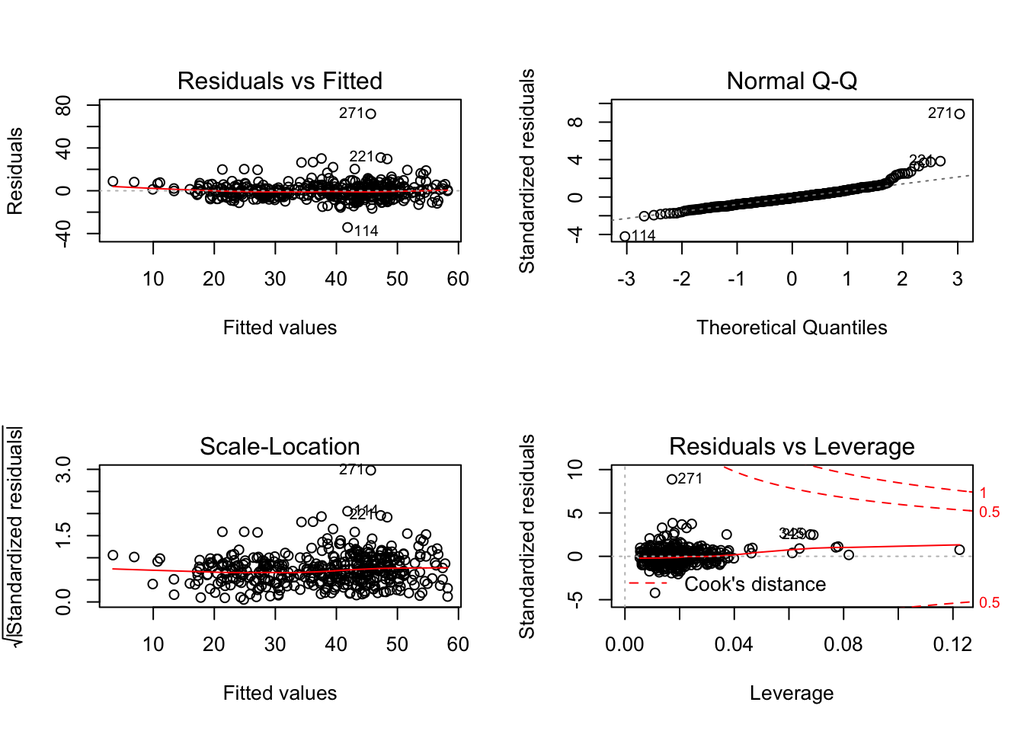

```r
# Plot diagnostic plots
oldpar = par(mfrow=c(2,2)) # 2 by 2 graphing region
plot(templm)
```

```r
par(oldpar)
```